# TAREFA 6 análise Fatorial e Análise de Correspondência - Análise Multivariada

Márcia Barbian

```r
library(tidyverse)
library(MASS)
library(psych)
library(GPArotation)
library(tidyverse)
library(FactoMineR)
library(factoextra)
library(GGally)
```

### Alunos: Diogo, Davi, João Arend, Thiago schedler e Gabriel.

# Exercício 1

As próximas perguntas são relacionados ao modelo fatorial ortogonal.

## a)

Indique a fórmula vetorial e matricial desse modelo, calcule sua esperança e sua variância.

### Resposta

**Fórmula vetorial:**

$$X_i = \mu_i + \lambda_{i1}F_1 + ... + \lambda_{im}F_m + \epsilon_i$$

Considerando:

- $X_i =$ i-ésima variável observada;
- $\mu_i =$ média de $X_i$;
- $\lambda_{im} =$ carga fatorial da i-ésima variável no fator m;
- $F_m =$ m-ésimo fator;
- $\epsilon_i =$ erro associado a i-ésima variável.

**Fórmula matricial:**

$$\begin{bmatrix}
X_1\\
X_2\\
\vdots\\
X_p
\end{bmatrix}
=
{\begin{bmatrix}
\mu_1\\
\mu_2\\
\vdots\\
\mu_p
\end{bmatrix}}
+
\bf{\Lambda}
{\begin{bmatrix}
F_1\\
F_2\\
\vdots\\
F_m
\end{bmatrix}}
+
{\begin{bmatrix}
\epsilon_1\\
\epsilon_2\\
\vdots\\
\epsilon_p
\end{bmatrix}}$$
na forma reduzida:

$${\bf X = \mu + \Lambda F + \epsilon}$$
Considerando:

- $\bf X =$ vetor de variáveis observadas;
- $\bf \mu =$ vetor de médias de $\bf X$;
- $\bf \Lambda =$ matriz ($p$ x $m$) de cargas fatoriais;
- $\bf F =$ vetor de fatores;
- $\bf \epsilon =$ vetor de erros.

**Esperança**

$$E({\bf X}) = E({\bf \mu + \Lambda F + \epsilon})$$
Usamos a suposição de que $E({\bf F}) = 0$ e $E({\bf \epsilon}) = 0$. Portanto:

$$E({\bf X}) = E({\bf\mu}) = {\bf \mu}$$

**Variância**

$${\bf \Sigma} = Var({\bf X}) = E[({\bf X - \mu})({\bf X - \mu})'] \\
{\bf \Sigma} = E[({\bf\Lambda F + \epsilon})({\bf\Lambda F +
\epsilon})'] \\
{\bf \Sigma} = E[{\bf\Lambda FF'\Lambda' + \Lambda F
\epsilon' + \epsilon F' \Lambda' + \epsilon \epsilon'}]$$

Aplicando as suposições do modelo:

$$FF' = I\\
E(F \epsilon') = 0\\
E(\epsilon F') = 0$$
Temos que:

$${\bf \Sigma = \Lambda I \Lambda + E(\epsilon \epsilon')} \\
{\bf \Sigma = \Lambda \Lambda' + \Psi}$$

- $\bf \Lambda \Lambda'$ é a matriz de covariâncias comuns.
- $\bf \Psi$ é a matriz de covariâncias específicas (erros).

## b)

Quais as suposições desse modelo e quais partes do modelos são fixas e quais são aleatórias?

### Responsta

**Suposições**

- Média de Fatores e Erros é zero: $E({\bf F}) = E(\epsilon) = 0$.
- Fatores ortogonais (não correlacionados): $Cov({\bf F}) = E({\bf FF'}) = I$
- Erros com média zero: $E(\epsilon) = 0$
- Erros não correlacionados e de mesma variância: $Cov(\epsilon) = E(\epsilon \epsilon') = \Psi$
- Fatores e erros independentes: $Cov({\bf F}, \epsilon) = E({\bf F}\epsilon') = 0$

**Fixas**

- $\mu$: Médias
- $\Lambda$: Cargas
- $\Psi$: Variâncias dos erros

**Aleatórias**

- $F$: Fatores
- $\epsilon$: Erros

# Exercício 2

O pacote *MASS* possui um conjunto de dados *Boston* composto por 506 observações de 14 variáveis que mensuram características de imóveis. Utilize as variáveis adequadas e responda as questôes abaixo.

- crim per capita crime rate by town.
- zn proportion of residential land zoned for lots over 25,000 sq.ft.
- indus proportion of non-retail business acres per town.
- chas Charles River dummy variable (= 1 if tract bounds river; 0 otherwise).
- nox nitrogen oxides concentration (parts per 10 million).
- rm average number of rooms per dwelling.
- age proportion of owner-occupied units built prior to 1940.
- dis weighted mean of distances to five Boston employment centres.
- rad index of accessibility to radial highways.
- tax full-value property-tax rate per $10,000.
- ptratio pupil-teacher ratio by town.
- black 1000(Bk - 0.63)^2 where Bk is the proportion of blacks by town.
- lstat lower status of the population (percent).
- medv median value of owner-occupied homes in $1000s.

```r
data(Boston, package = "MASS")
banco_dados <- Boston
#glimpse(banco_dados)
#summary(banco_dados)

banco_dados <- subset(banco_dados, select = -c(chas, rad))
```

## a)

1. Faça uma análise gráfica desse conjunto de dados.
2. Dado que *m* é o número de fatores utilizado, qual o valor de *m* que você definiria para este exercício? Justifique.

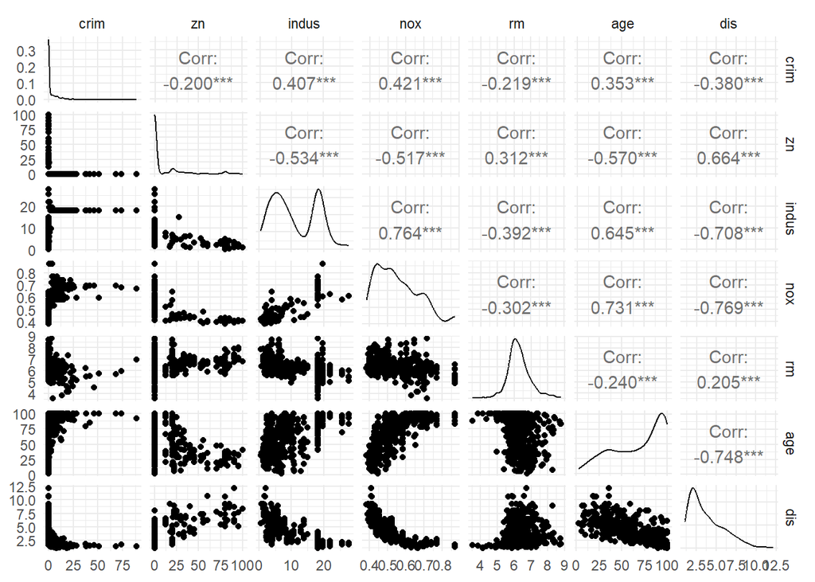

```r
ggpairs(banco_dados[, 1:7], progress = FALSE) +
  theme_minimal()
```

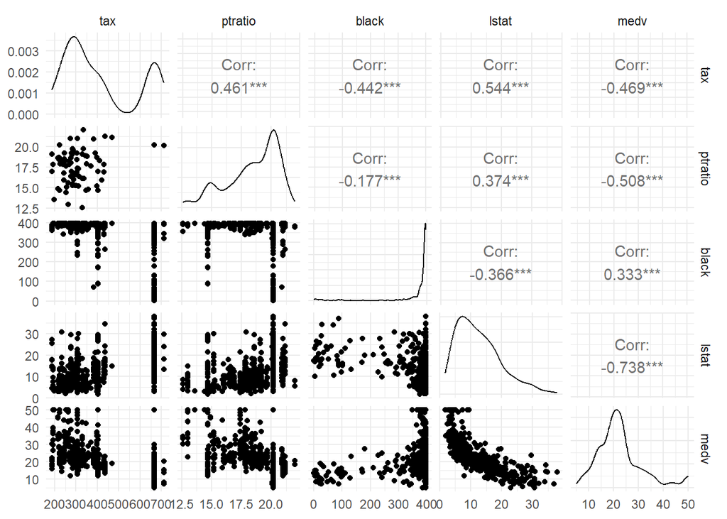

```r
ggpairs(banco_dados[, 8:12], progress = FALSE) +
  theme_minimal()
```

Para escolha do número m de fatores, um critério é considerar somente fatores que possuam autovalores maiores que 1.

```r
R = cor(banco_dados)
eigen(R)$values
```

```
##  [1] 5.9879999 1.5173857 1.1365994 0.8113500 0.6437476 0.5227496 0.4013911
##  [8] 0.2555344 0.2141050 0.1908536 0.1823074 0.1359763
```

```r
componentes_principais = res.pca <- prcomp(banco_dados, scale = TRUE)
summary(componentes_principais)
```

```
## Importance of components:
##                          PC1    PC2     PC3     PC4     PC5     PC6     PC7
## Standard deviation     2.447 1.2318 1.06611 0.90075 0.80234 0.72301 0.63355
## Proportion of Variance 0.499 0.1265 0.09472 0.06761 0.05365 0.04356 0.03345
## Cumulative Proportion  0.499 0.6254 0.72017 0.78778 0.84142 0.88499 0.91844
##                            PC8     PC9   PC10    PC11    PC12
## Standard deviation     0.50550 0.46271 0.4369 0.42697 0.36875
## Proportion of Variance 0.02129 0.01784 0.0159 0.01519 0.01133
## Cumulative Proportion  0.93973 0.95757 0.9735 0.98867 1.00000
```

Os 3 primeiros autovalores são maiores que 1 e explicam 72% da variabilidade.

## b)

Aplique a Análise Fatorial utilizando Fatores Principais. Interprete os resultados, o que cada fator explica?

```r
fatores_sem_rotacao = principal(banco_dados, nfactors = 3, rotate = "none", residuals = TRUE)

print(round(fatores_sem_rotacao$communality, 2))
```

```
##    crim      zn   indus     nox      rm     age     dis     tax ptratio   black
##    0.63    0.70    0.76    0.81    0.76    0.76    0.87    0.74    0.45    0.59
##   lstat    medv
##    0.74    0.84
```

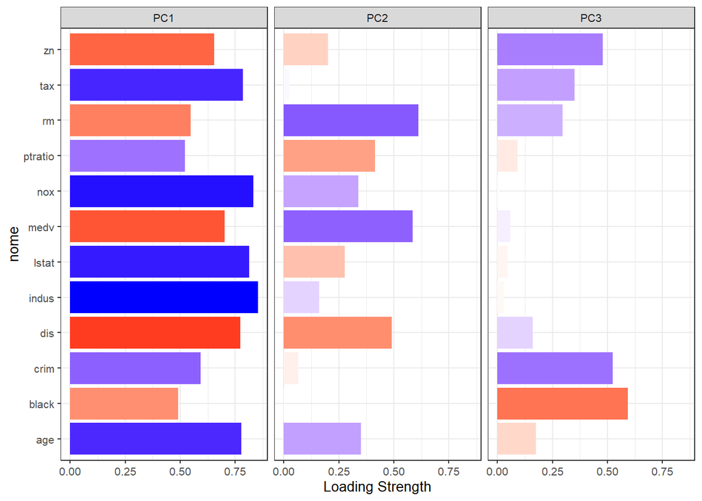

```r
load=fatores_sem_rotacao$loadings[,1:3]
load=as.data.frame(load)
load["nome"]=as.factor(row.names(load))

require(data.table)

loadings.m <- melt(load, id="nome",
                   measure=c("PC1", "PC2", "PC3"),
                   variable.name="Factor", value.name="Loading")

cargas_sem_rotacao = ggplot(loadings.m, aes(nome, abs(Loading), fill=Loading)) +
  facet_wrap(~ Factor, nrow=1) +
  geom_bar(stat="identity") +
  coord_flip() +
  scale_fill_gradient2(name = "Loading",
                       high = "blue", mid = "white", low = "red",
                       midpoint=0, guide=F) +
  ylab("Loading Strength") +
  theme_bw(base_size=10)
cargas_sem_rotacao
```

## c)

Aplique a Análise Fatorial utilizando rotação varimax. Interprete os resultados, o que cada fator explica?

```r
fatores_varimax = principal(banco_dados, nfactors = 3, rotate = "varimax")

print(round(fatores_varimax$communality, 2))
```

```
##    crim      zn   indus     nox      rm     age     dis     tax ptratio   black
##    0.63    0.70    0.76    0.81    0.76    0.76    0.87    0.74    0.45    0.59
##   lstat    medv
##    0.74    0.84
```

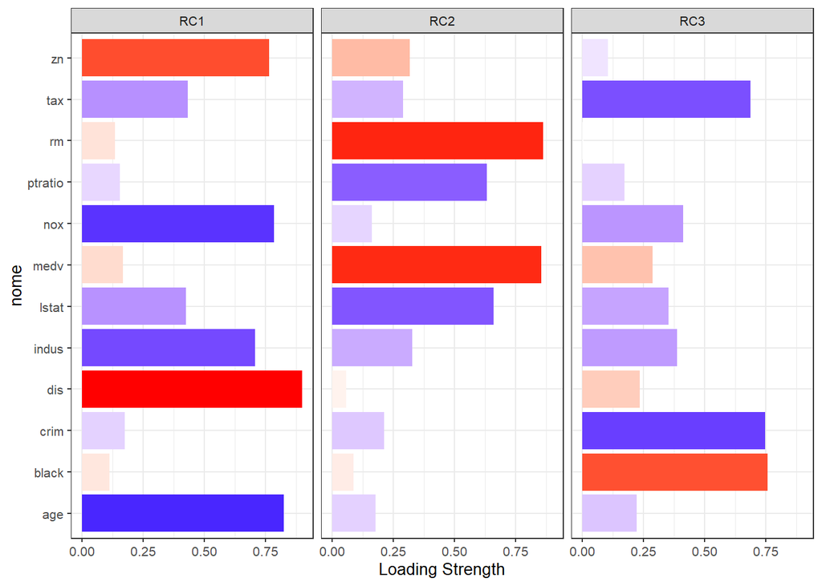

```r
load=fatores_varimax$loadings[,1:3]
load=as.data.frame(load)
load["nome"]=as.factor(row.names(load))

require(data.table)

loadings.m <- melt(load, id="nome",
                   measure=c("RC1", "RC2", "RC3"),
                   variable.name="Factor", value.name="Loading")

cargas = ggplot(loadings.m, aes(nome, abs(Loading), fill=Loading)) +
  facet_wrap(~ Factor, nrow=1) +
  geom_bar(stat="identity") +
  coord_flip() +
  scale_fill_gradient2(name = "Loading",
                       high = "blue", mid = "white", low = "red",
                       midpoint=0, guide=F) +
  ylab("Loading Strength") +
  theme_bw(base_size=10)

cargas
```

## d)

Compare os resultados de b) e c). O que você conclui?

## e)

Calcule as correlações residuais de b) e c) e interprete.

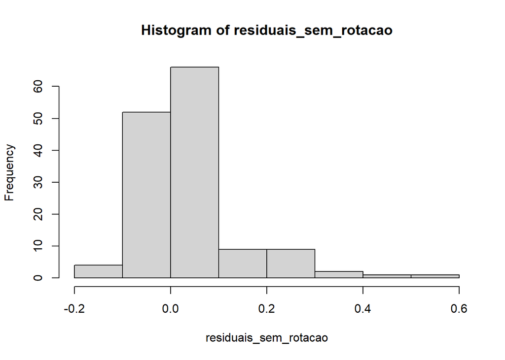

```r
residuais_sem_rotacao <- fatores_sem_rotacao$residual

residuais_varimax <- fatores_varimax$residual



hist(residuais_sem_rotacao)
```

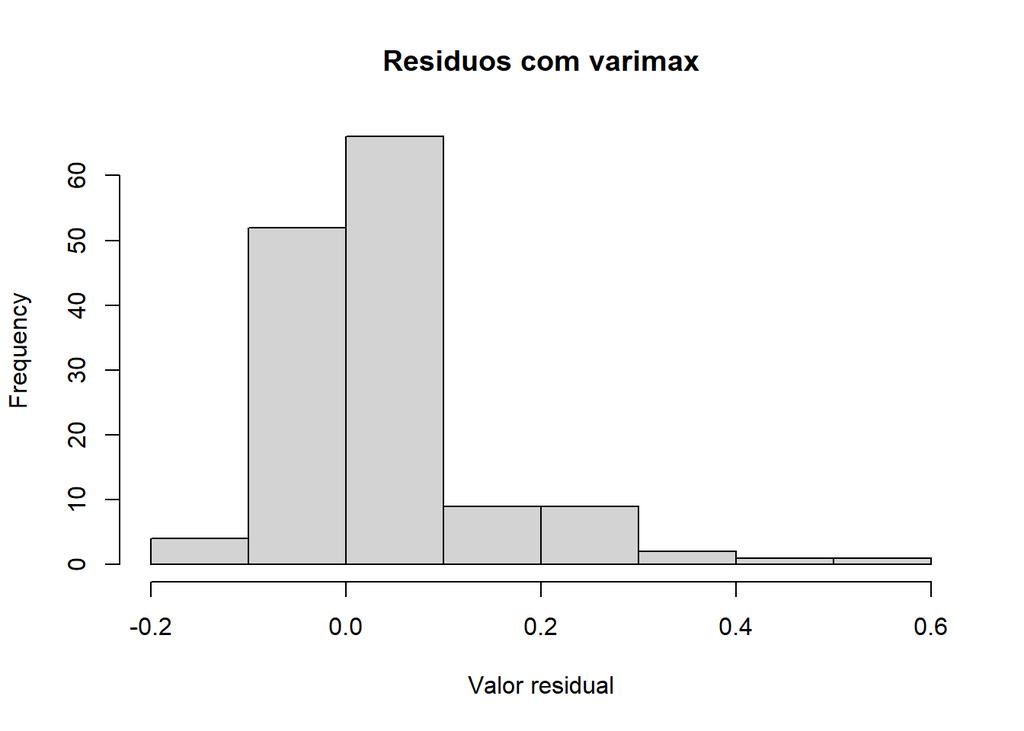

```r
hist(residuais_varimax, main="Residuos com varimax", xlab="Valor residual")
```

Os resíduos de ambos os fatores são os mesmos, tanto com o varimax e sem a rotação. A rotação varimax é uma transformação ortogonal que apenas reorganiza as cargas fatoriais para facilitar a interpretação. Portanto é rasoável que a distribuição resídual deva ser a mesma.

Além disso, a média de ambas as distribuições é próxima de zero (0,0321) com poucos resíduos extremos, portanto não há indícios de correlações não explicadas.

# Exercício 3

O que é análise de correspondência? Quando ela deve ser utilizada?

## Resposta

Análise de Correspondência é uma técnica para explorar e visualizar as relações de associação entre variáveis categóricas. Criando um ‘mapa’ de dispersão no qual variáveis mais associadas ficam mais próximas entre si.

O principal objetivo da Análise de Correspondência é simplificar a interpretação de tabelas complexas, revelando possíveis padrões de relacionamento entre as categorias, permitindo identificar quais categorias de uma variável estão mais associadas a quais categorias de outra.

A aplicação é semelhante ao PCA para dados contínuos, ou seja, quando queremos explorar associações, reduzir dimensionalidade, visualizar dados complexos…

# Exercício 4

O banco de dados que deve ser analisado nesse exercício é o titanic, ele é composto por variáveis referentes a características dos passageiros e tripulantes do titanic como idade, sexo e classe.

Para esse exercício utilize a variável idade categorizada.

```r
#install.packages("titanic")
library(titanic)
data("titanic_train")

# Remover NAs em Age e Embarked
# Criar faixa etária e transformar em fatores as variáveis que estão como números

base_titanic <- titanic_train %>%
  filter(!is.na(Age), !is.na(Embarked)) %>%
    mutate(
      Survived = factor(Survived, labels = c("Não", "Sim")),
      Pclass = factor(Pclass, labels = c("1ª", "2ª", "3ª")),
      AgeGroup = cut(Age, breaks = c(0, 12, 18, 30, 50, Inf),
                     labels = c("Criança", "Adolescente", "Jovem Adulto", "Adulto", "Idoso")),
      Sex = factor(Sex)
      )


str(base_titanic)
```

```
## 'data.frame':    714 obs. of  13 variables:
##  $ PassengerId: int  1 2 3 4 5 7 8 9 10 11 ...
##  $ Survived   : Factor w/ 2 levels "Não","Sim": 1 2 2 2 1 1 1 2 2 2 ...
##  $ Pclass     : Factor w/ 3 levels "1ª","2ª","3ª": 3 1 3 1 3 1 3 3 2 3 ...
##  $ Name       : chr  "Braund, Mr. Owen Harris" "Cumings, Mrs. John Bradley (Florence Briggs Thayer)" "Heikkinen, Miss. Laina" "Futrelle, Mrs. Jacques Heath (Lily May Peel)" ...
##  $ Sex        : Factor w/ 2 levels "female","male": 2 1 1 1 2 2 2 1 1 1 ...
##  $ Age        : num  22 38 26 35 35 54 2 27 14 4 ...
##  $ SibSp      : int  1 1 0 1 0 0 3 0 1 1 ...
##  $ Parch      : int  0 0 0 0 0 0 1 2 0 1 ...
##  $ Ticket     : chr  "A/5 21171" "PC 17599" "STON/O2. 3101282" "113803" ...
##  $ Fare       : num  7.25 71.28 7.92 53.1 8.05 ...
##  $ Cabin      : chr  "" "C85" "" "C123" ...
##  $ Embarked   : chr  "S" "C" "S" "S" ...
##  $ AgeGroup   : Factor w/ 5 levels "Criança","Adolescente",..: 3 4 3 4 4 5 1 3 2 1 ...
```

## a)

Considere as variáveis Survived e Pclass. Faça um mosaic plot e um buble plot desses dados.

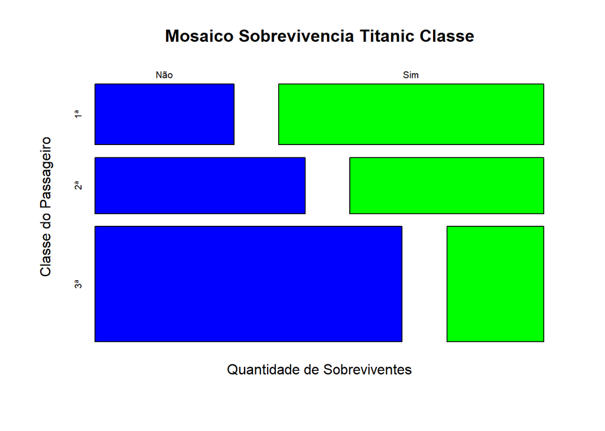

```r
library(vcd)
library(ggmosaic)

# mosaic plot

df <- table(base_titanic$Pclass,base_titanic$Survived)

mosaicplot(df,
           main = "Mosaico Sobrevivencia Titanic Classe",
           ylab = "Classe do Passageiro",
           xlab = "Quantidade de Sobreviventes",
           col = c("blue", "green"),
           off = 10,
           dir = c("h","v"))
```

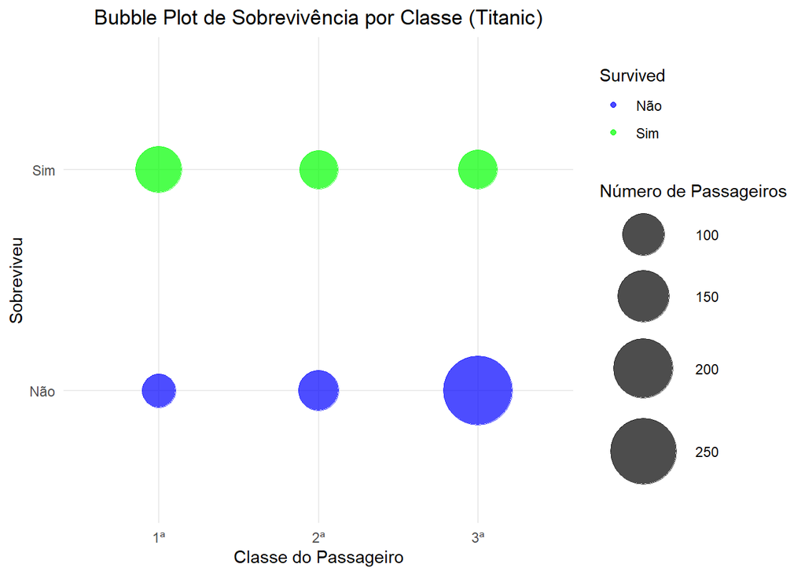

```r
# bubble plot
dados_plot <- as.data.frame(df)
colnames(dados_plot) <- c("Pclass", "Survived", "Count")
ggplot(dados_plot, aes(x = Pclass, y = Survived, size = Count, color = Survived)) +
  geom_point(alpha = 0.7) +
  scale_size_area(max_size = 20) +
  scale_color_manual(values = c("Não" = "blue", "Sim" = "green")) +
  labs(
    title = "Bubble Plot de Sobrevivência por Classe (Titanic)",
    x = "Classe do Passageiro",
    y = "Sobreviveu",
    size = "Número de Passageiros"
  ) +
  theme_minimal() +
  theme(plot.title = element_text(hjust = 0.5))
```

## b)

Considere as variáveis Survived e Pclass. Faça a análise de correspondência, faça o biplot e interprete os resultados.

```r
library(FactoMineR)
library(factoextra)

res_ca <- CA(df, graph = FALSE)
print(res_ca)
```

```
## **Results of the Correspondence Analysis (CA)**
## The row variable has  3  categories; the column variable has 2 categories
## The chi square of independence between the two variables is equal to 92.90142 (p-value =  6.709862e-21 ).
## *The results are available in the following objects:
##
##    name              description
## 1  "$eig"            "eigenvalues"
## 2  "$col"            "results for the columns"
## 3  "$col$coord"      "coord. for the columns"
## 4  "$col$cos2"       "cos2 for the columns"
## 5  "$col$contrib"    "contributions of the columns"
## 6  "$row"            "results for the rows"
## 7  "$row$coord"      "coord. for the rows"
## 8  "$row$cos2"       "cos2 for the rows"
## 9  "$row$contrib"    "contributions of the rows"
## 10 "$call"           "summary called parameters"
## 11 "$call$marge.col" "weights of the columns"
## 12 "$call$marge.row" "weights of the rows"
```

```r
get_ca_row(res_ca)$contrib
```

```
##        1ª        2ª        3ª
## 51.777304  4.182987 44.039709
```

```r
get_eigenvalue(res_ca)
```

```
##       eigenvalue variance.percent cumulative.variance.percent
## Dim.1   0.130114              100                         100
```

## c)

Considere as variáveis Survived e Sex. Faça um mosaic plot e um buble plot desses dados.

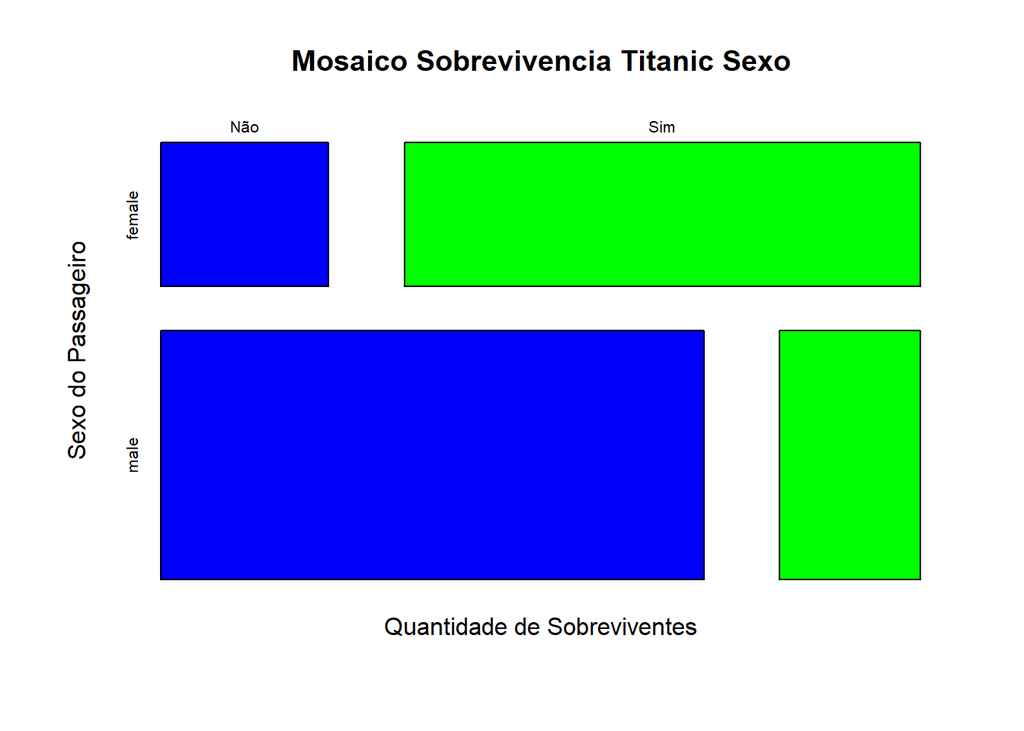

```r
# mosaic plot

df1 <- table(base_titanic$Sex,base_titanic$Survived)

mosaicplot(df1,
           main = "Mosaico Sobrevivencia Titanic Sexo",
           ylab = "Sexo do Passageiro",
           xlab = "Quantidade de Sobreviventes",
           col = c("blue", "green"),
           off = 10,
           dir = c("h","v"))
```

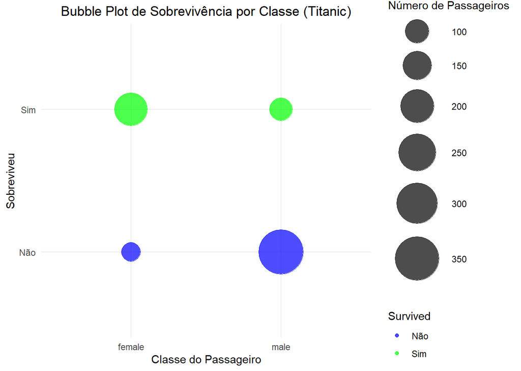

```r
# buble plot
dados_plot1 <- as.data.frame(df1)
colnames(dados_plot1) <- c("Sexo", "Survived", "Count")
ggplot(dados_plot1, aes(x = Sexo, y = Survived, size = Count, color = Survived)) +
  geom_point(alpha = 0.7) +
  scale_size_area(max_size = 20) +
  scale_color_manual(values = c("Não" = "blue", "Sim" = "green")) +
  labs(
    title = "Bubble Plot de Sobrevivência por Classe (Titanic)",
    x = "Classe do Passageiro",
    y = "Sobreviveu",
    size = "Número de Passageiros"
  ) +
  theme_minimal() +
  theme(plot.title = element_text(hjust = 0.5))
```

## d)

Considere as variáveis Survived e Sex. Faça a análise de correspondência, faça o biplot e interprete os resultados.

```r
res_ca1 <- CA(df1, graph = FALSE)
print(res_ca1)
```

```
## **Results of the Correspondence Analysis (CA)**
## The row variable has  2  categories; the column variable has 2 categories
## The chi square of independence between the two variables is equal to 207.2978 (p-value =  5.33866e-47 ).
## *The results are available in the following objects:
##
##    name              description
## 1  "$eig"            "eigenvalues"
## 2  "$col"            "results for the columns"
## 3  "$col$coord"      "coord. for the columns"
## 4  "$col$cos2"       "cos2 for the columns"
## 5  "$col$contrib"    "contributions of the columns"
## 6  "$row"            "results for the rows"
## 7  "$row$coord"      "coord. for the rows"
## 8  "$row$cos2"       "cos2 for the rows"
## 9  "$row$contrib"    "contributions of the rows"
## 10 "$call"           "summary called parameters"
## 11 "$call$marge.col" "weights of the columns"
## 12 "$call$marge.row" "weights of the rows"
```

```r
get_ca_row(res_ca1)$contrib
```

```
##   female     male
## 63.44538 36.55462
```

```r
get_eigenvalue(res_ca1)
```

```
##       eigenvalue variance.percent cumulative.variance.percent
## Dim.1   0.290333              100                         100
```

## e)

Considere as variáveis Survived e AgeGroup. Faça um mosaic plot e um buble plot desses dados.

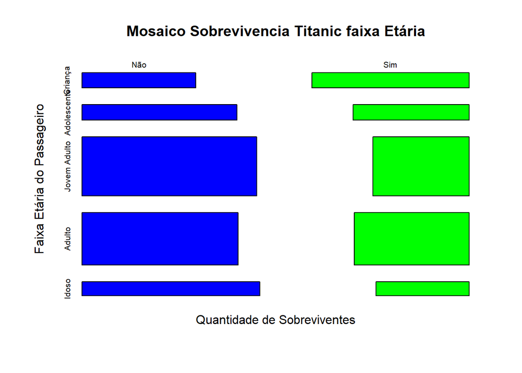

```r
df2 <- table(base_titanic$AgeGroup,base_titanic$Survived)

mosaicplot(df2,
           main = "Mosaico Sobrevivencia Titanic faixa Etária",
           ylab = "Faixa Etária do Passageiro",
           xlab = "Quantidade de Sobreviventes",
           col = c("blue", "green"),
           off = 30,
           dir = c("h","v"))
```

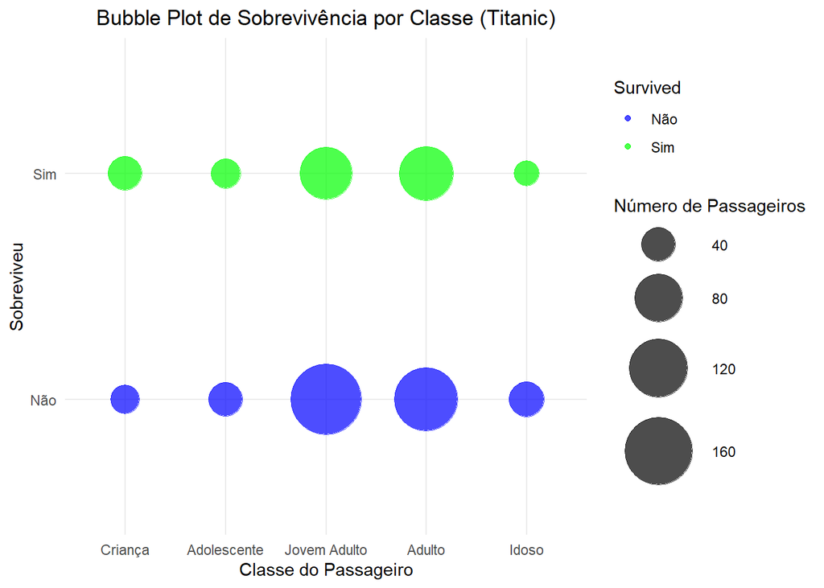

```r
# buble plot
dados_plot2 <- as.data.frame(df2)
colnames(dados_plot2) <- c("Idade", "Survived", "Count")
ggplot(dados_plot2, aes(x = Idade, y = Survived, size = Count, color = Survived)) +
  geom_point(alpha = 0.7) +
  scale_size_area(max_size = 20) +
  scale_color_manual(values = c("Não" = "blue", "Sim" = "green")) +
  labs(
    title = "Bubble Plot de Sobrevivência por Classe (Titanic)",
    x = "Classe do Passageiro",
    y = "Sobreviveu",
    size = "Número de Passageiros"
  ) +
  theme_minimal() +
  theme(plot.title = element_text(hjust = 0.5))
```

## f)

Considere as variáveis Survived e AgeGroup. Faça a análise de correspondência, faça o biplot e interprete os resultados.

```r
res_ca2 <- CA(df2, graph = FALSE)
print(res_ca2)
```

```
## **Results of the Correspondence Analysis (CA)**
## The row variable has  5  categories; the column variable has 2 categories
## The chi square of independence between the two variables is equal to 12.95383 (p-value =  0.01150363 ).
## *The results are available in the following objects:
##
##    name              description
## 1  "$eig"            "eigenvalues"
## 2  "$col"            "results for the columns"
## 3  "$col$coord"      "coord. for the columns"
## 4  "$col$cos2"       "cos2 for the columns"
## 5  "$col$contrib"    "contributions of the columns"
## 6  "$row"            "results for the rows"
## 7  "$row$coord"      "coord. for the rows"
## 8  "$row$cos2"       "cos2 for the rows"
## 9  "$row$contrib"    "contributions of the rows"
## 10 "$call"           "summary called parameters"
## 11 "$call$marge.col" "weights of the columns"
## 12 "$call$marge.row" "weights of the rows"
```

```r
get_ca_row(res_ca2)$contrib
```

```
##      Criança  Adolescente Jovem Adulto       Adulto        Idoso
##    66.515253     1.125061    22.131861     2.248664     7.979160
```

```r
get_eigenvalue(res_ca2)
```

```
##       eigenvalue variance.percent cumulative.variance.percent
## Dim.1 0.01814261              100                         100
```

- O teste indica que existe uma relação estatisticamente significativa entre a sobrevivência do passageiro e sua faixa etária.
- Notamos que a categoria ‘Criança’ tem um peso maior na definição dessa dimensão, ou seja, há uma diferença maior na variação das crianças que sobreviveram dos demais grupos.

## g)

Qual das variáveis explica melhor a sobrevivência ou não no titanic? Se você tivesse que fazer uma análise de correspondência multipla, com 3 variáveis, quais seriam?

A análise dos eigenvalues revelou que a variável Sex (Gênero) demonstra a maior associação com Survived (Sobrevivência), indicando que o gênero é o fator individual mais influente na explicação da sobrevivencia do passageiro. Para uma Análise de Correspondência Múltipla, as variáveis ‘Survived’, ‘Sex’ e ‘Pclass’ seriam as escolhas mais adequadas.